# NFL_MLProject

## Datasets

Following link allows you to download the dataset in a csv format. To view the full directory of the project, click below.

all_game_results_clean.csv  
 player_game_stats.csv  
 nfl_pass_rush_receive_raw_data.csv  
 all_game_results.csv  
 NFL ELO Data

# Nature of the Data

# Data Cleaning/Preprocessing

First data set obtained was the on-field data along with game-specific variable ‘Is_Evening_Game’ which classifies if the game occurred before 1pm or not which we assumed could impact the performance of the players. For team name abbreviations, we followed the official NFL abbreviation and recorded the most recent name if any change was found. Next was team ELO data based on the ELO rating system that takes into account the relative strength of the opposition that can successfully gauge team’s relative strengths and potentially enhance the predictive performance of our model by measuring the relative difficulty of the game for each team. We cross check our data set from years 1977 ~ present from other data sets for accuracy. This was merged with our previous dataset using the unique gameID(‘Date format’ + ‘hometeam’).

```python
all_game_results_clean = pd.read_csv('all_game_results_clean.csv')
player_game_stats = pd.read_csv('player_game_stats.csv')
el = pd.read_csv('https://raw.githubusercontent.com/fivethirtyeight/nfl-elo-game/master/data/nfl_games.csv')
el.head()
```

|  | date | season | neutral | playoff | team1 | team2 | elo1 | elo2 | elo_prob1 | score1 | score2 | result1 |
| --- | --- | --- | --- | --- | --- | --- | --- | --- | --- | --- | --- | --- |
| 0 | 1920-09-26 | 1920 | 0 | 0 | RII | STP | 1503.947 | 1300.000 | 0.824651 | 48 | 0 | 1.0 |
| 1 | 1920-10-03 | 1920 | 0 | 0 | AKR | WHE | 1503.420 | 1300.000 | 0.824212 | 43 | 0 | 1.0 |
| 2 | 1920-10-03 | 1920 | 0 | 0 | RCH | ABU | 1503.420 | 1300.000 | 0.824212 | 10 | 0 | 1.0 |
| 3 | 1920-10-03 | 1920 | 0 | 0 | DAY | COL | 1493.002 | 1504.908 | 0.575819 | 14 | 0 | 1.0 |
| 4 | 1920-10-03 | 1920 | 0 | 0 | RII | MUN | 1516.108 | 1478.004 | 0.644171 | 45 | 0 | 1.0 |

```python
all_game_results_clean.head()
```

|  | Unnamed: 0 | Week | Day | Date | Time | Winner/tie | Unnamed: 5 | Loser/tie | Unnamed: 7 | PtsW | PtsL | YdsW | TOW | YdsL | TOL | time_date | game_id |
| --- | --- | --- | --- | --- | --- | --- | --- | --- | --- | --- | --- | --- | --- | --- | --- | --- | --- |
| 0 | 0 | 1 | Sun | 1977-09-18 | 1:00PM | Atlanta Falcons | NaN | Los Angeles Rams | boxscore | 17 | 6 | 264 | 0 | 167 | 3 | 1977-09-18 13:00:00 | 19770918ATL |
| 1 | 1 | 1 | Sun | 1977-09-18 | 1:00PM | Miami Dolphins | @ | Buffalo Bills | boxscore | 13 | 0 | 148 | 0 | 324 | 4 | 1977-09-18 13:00:00 | 19770918BUF |
| 2 | 2 | 1 | Sun | 1977-09-18 | 1:00PM | New York Giants | NaN | Washington Redskins | boxscore | 20 | 17 | 279 | 1 | 261 | 2 | 1977-09-18 13:00:00 | 19770918NYG |
| 3 | 3 | 1 | Sun | 1977-09-18 | 1:00PM | New England Patriots | NaN | Kansas City Chiefs | boxscore | 21 | 17 | 381 | 4 | 335 | 2 | 1977-09-18 13:00:00 | 19770918NE |
| 4 | 4 | 1 | Sun | 1977-09-18 | 1:00PM | Cleveland Browns | @ | Cincinnati Bengals | boxscore | 13 | 3 | 285 | 3 | 245 | 3 | 1977-09-18 13:00:00 | 19770918CIN |

```python
player_game_stats.head()
```

|  | Unnamed: 0 | game_id | player_id | pos | player | team | pass_cmp | pass_att | pass_yds | pass_td | ... | OT | Roof | Surface | Temperature | Humidity | Wind_Speed | Vegas_Line | Vegas_Favorite | Over_Under | game_date |
| --- | --- | --- | --- | --- | --- | --- | --- | --- | --- | --- | --- | --- | --- | --- | --- | --- | --- | --- | --- | --- | --- |
| 0 | 0 | 20190905CHI | RodgAa00 | QB | Aaron Rodgers | GNB | 18 | 30 | 203 | 1 | ... | False | outdoors | grass | 65 | 69 | 10 | -3.5 | CHI | 47.0 | 2019-09-05 |
| 1 | 1 | 20190905CHI | JoneAa00 | RB | Aaron Jones | GNB | 0 | 0 | 0 | 0 | ... | False | outdoors | grass | 65 | 69 | 10 | -3.5 | CHI | 47.0 | 2019-09-05 |
| 2 | 2 | 20190905CHI | ValdMa00 | WR | Marquez Valdes-Scantling | GNB | 0 | 0 | 0 | 0 | ... | False | outdoors | grass | 65 | 69 | 10 | -3.5 | CHI | 47.0 | 2019-09-05 |
| 3 | 3 | 20190905CHI | AdamDa01 | WR | Davante Adams | GNB | 0 | 0 | 0 | 0 | ... | False | outdoors | grass | 65 | 69 | 10 | -3.5 | CHI | 47.0 | 2019-09-05 |
| 4 | 4 | 20190905CHI | GrahJi00 | TE | Jimmy Graham | GNB | 0 | 0 | 0 | 0 | ... | False | outdoors | grass | 65 | 69 | 10 | -3.5 | CHI | 47.0 | 2019-09-05 |

5 rows × 70 columns

```python
elo = el.drop(["neutral", "playoff","elo_prob1", "score1", "score2"], axis =1)
ell = elo[elo['season'] > 1976]
ell["team1"]= ell["team1"].str.upper()
ell["team2"]= ell["team2"].str.upper()
ell["team1"] = ell["team1"].replace({'ARI': 'ARZ', 'OAK': 'LV', 'CLE':'CLV','WSH':'WAS','BAL':'BLT', 'HOU':'HST'})
ell["team2"] = ell["team2"].replace({'ARI': 'ARZ', 'OAK': 'LV', 'CLE':'CLV','WSH':'WAS','BAL':'BLT', 'HOU':'HST'})
ell.head()
```

|  | date | season | team1 | team2 | elo1 | elo2 | result1 |
| --- | --- | --- | --- | --- | --- | --- | --- |
| 5886 | 1977-09-18 | 1977 | LV | LAC | 1679.742 | 1455.663 | 1.0 |
| 5887 | 1977-09-18 | 1977 | ATL | LAR | 1410.208 | 1600.555 | 1.0 |
| 5888 | 1977-09-18 | 1977 | CHI | DET | 1476.481 | 1479.919 | 1.0 |
| 5889 | 1977-09-18 | 1977 | SEA | IND | 1303.525 | 1573.674 | 0.0 |
| 5890 | 1977-09-18 | 1977 | PHI | TB | 1422.747 | 1280.515 | 1.0 |

```python
ell['date'] = ell['date'].str.replace('-','')
ell.head()
```

|  | date | season | team1 | team2 | elo1 | elo2 | result1 |
| --- | --- | --- | --- | --- | --- | --- | --- |
| 5886 | 19770918 | 1977 | LV | LAC | 1679.742 | 1455.663 | 1.0 |
| 5887 | 19770918 | 1977 | ATL | LAR | 1410.208 | 1600.555 | 1.0 |
| 5888 | 19770918 | 1977 | CHI | DET | 1476.481 | 1479.919 | 1.0 |
| 5889 | 19770918 | 1977 | SEA | IND | 1303.525 | 1573.674 | 0.0 |
| 5890 | 19770918 | 1977 | PHI | TB | 1422.747 | 1280.515 | 1.0 |

```python
ell["gameID"] = ell["date"] + ell["team1"]
ell["gameID"] = ell["gameID"].str.lower()
ell["date"] = ell["gameID"]
ell = ell.drop(["date"], axis = 1)
first_column = ell.pop('gameID')
ell.insert(0, 'gameID', first_column)
ell.head()
```

|  | gameID | season | team1 | team2 | elo1 | elo2 | result1 |
| --- | --- | --- | --- | --- | --- | --- | --- |
| 5886 | 19770918lv | 1977 | LV | LAC | 1679.742 | 1455.663 | 1.0 |
| 5887 | 19770918atl | 1977 | ATL | LAR | 1410.208 | 1600.555 | 1.0 |
| 5888 | 19770918chi | 1977 | CHI | DET | 1476.481 | 1479.919 | 1.0 |
| 5889 | 19770918sea | 1977 | SEA | IND | 1303.525 | 1573.674 | 0.0 |
| 5890 | 19770918phi | 1977 | PHI | TB | 1422.747 | 1280.515 | 1.0 |

```python
all_game_results_clean.head()
```

|  | Unnamed: 0 | Week | Day | Date | Time | Winner/tie | Unnamed: 5 | Loser/tie | Unnamed: 7 | PtsW | PtsL | YdsW | TOW | YdsL | TOL | time_date | game_id |
| --- | --- | --- | --- | --- | --- | --- | --- | --- | --- | --- | --- | --- | --- | --- | --- | --- | --- |
| 0 | 0 | 1 | Sun | 1977-09-18 | 1:00PM | Atlanta Falcons | NaN | Los Angeles Rams | boxscore | 17 | 6 | 264 | 0 | 167 | 3 | 1977-09-18 13:00:00 | 19770918ATL |
| 1 | 1 | 1 | Sun | 1977-09-18 | 1:00PM | Miami Dolphins | @ | Buffalo Bills | boxscore | 13 | 0 | 148 | 0 | 324 | 4 | 1977-09-18 13:00:00 | 19770918BUF |
| 2 | 2 | 1 | Sun | 1977-09-18 | 1:00PM | New York Giants | NaN | Washington Redskins | boxscore | 20 | 17 | 279 | 1 | 261 | 2 | 1977-09-18 13:00:00 | 19770918NYG |
| 3 | 3 | 1 | Sun | 1977-09-18 | 1:00PM | New England Patriots | NaN | Kansas City Chiefs | boxscore | 21 | 17 | 381 | 4 | 335 | 2 | 1977-09-18 13:00:00 | 19770918NE |
| 4 | 4 | 1 | Sun | 1977-09-18 | 1:00PM | Cleveland Browns | @ | Cincinnati Bengals | boxscore | 13 | 3 | 285 | 3 | 245 | 3 | 1977-09-18 13:00:00 | 19770918CIN |

```python
def uppercase(x):
    return x.upper()

ell['gameID'] = ell['gameID'].apply(uppercase)
```

```python
game_results_w_elo = all_game_results_clean.merge(ell, left_on = ['game_id'], right_on = ['gameID'])
```

Then, we incorporated player data from Pro Football Reference which was provided in a HTML format(multi-indexed) so we made a function to iterate and scrape data into a .csv file. Data was also cross checked with our existing data and fixed/updated team names and merged with gameID with our data set. The original game data was multi-indexed so we had to parse through each game and each team to retrieve the specific player we needed for modeling. For each game, we isolated the primary QB stats (if more than one QB plays in a game, the one with the higher total average will be chosen) and recorded a rolling average of the player statistics: fumbles_lost,two_point_conversion, and pass_long. We then calculated the difference (home team - away team) in a value of a given statistic (column) between the primary home team QB and away team QB. ‘Vegas_Favorite_difference’ was also calculated as one of the dependent variables for our data which measures the likelihood of a particular outcome. Positive values would favor the home team and negative values would favor the away team.

```python
import pandas as pd
import numpy as np
import matplotlib.pyplot as plt
import time

results = []

for i in range(1977, 2021):
    url = "https://www.pro-football-reference.com/years/" + str(i) + "/games.htm"
    #df = pd.read_html(url)
    results += df
```

```python
all_game_results = pd.read_csv('all_game_results.csv')
```

```python
team_abbrev = {
 'St. Louis Rams' : 'LAR',
 'Phoenix Cardinals' : 'ARZ',
 'Los Angeles Raiders' : 'LV',
 'San Diego Chargers' : 'LAC',
 'Baltimore Colts' : 'IND',
  'St. Louis Cardinals' : 'ARZ',
  'Houston Oilers' : 'TEN',
 'Tennessee Oilers' : 'TEN',
 'Arizona Cardinals': 'ARZ',
 'Atlanta Falcons': 'ATL',
 'Baltimore Ravens': 'BLT',
 'Buffalo Bills': 'BUF',
 'Carolina Panthers': 'CAR',
 'Chicago Bears': 'CHI',
 'Cincinnati Bengals': 'CIN',
 'Cleveland Browns': 'CLV',
 'Dallas Cowboys': 'DAL',
 'Denver Broncos': 'DEN',
 'Detroit Lions': 'DET',
 'Green Bay Packers': 'GB',
 'Houston Texans': 'HST',
 'Indianapolis Colts': 'IND',
 'Jacksonville Jaguars': 'JAX',
 'Kansas City Chiefs': 'KC',
 'Las Vegas Raiders': 'LV',
 'Los Angeles Chargers': 'LAC',
 'Los Angeles Rams': 'LAR',
 'Miami Dolphins': 'MIA',
 'Minnesota Vikings': 'MIN',
 'New England Patriots': 'NE',
 'New Orleans Saints': 'NO',
 'New York Giants': 'NYG',
 'New York Jets': 'NYJ',
 'Oakland Raiders': 'LV',
 'Philadelphia Eagles': 'PHI',
 'Pittsburgh Steelers': 'PIT',
 'San Francisco 49ers': 'SF',
 'Seattle Seahawks': 'SEA',
 'Tampa Bay Buccaneers': 'TB',
 'Tennessee Titans': 'TEN',
 'Washington Football Team': 'WAS',
 'Washington Redskins': 'WAS'
}

abbrev_corrections = {
    'atl': 'ATL',
 'buf': 'BUF',
 'car': 'CAR',
 'chi': 'CHI',
 'cin': 'CIN',
 'cle': 'CLV',
 'clt': 'IND',
 'crd': 'ARZ',
 'dal': 'DAL',
 'den': 'DEN',
 'det': 'DET',
 'gnb': 'GB',
 'htx': 'HST',
 'jax': 'JAX',
 'kan': 'KC',
 'mia': 'MIA',
 'min': 'MIN',
 'nor': 'NO',
 'nwe': 'NE',
 'nyg': 'NYG',
 'nyj': 'NYJ',
 'oti': 'TEN',
 'phi': 'PHI',
 'pit': 'PIT',
 'rai': 'LV',
 'ram': 'LAR',
 'rav': 'BLT',
 'sdg': 'LAC',
 'sea': 'SEA',
 'sfo': 'SF',
 'tam': 'TB',
 'was': 'WAS'
}
```

```python
# player_stats.csv

player_game_stats = pd.read_csv('nfl_pass_rush_receive_raw_data.csv')

def fix_game_id(game_id):
    old_abbrev = game_id[-3:]
    new_abbrev = abbrev_corrections[old_abbrev]
    return game_id[:-4] + new_abbrev

player_game_stats_fixed_abbev = player_game_stats.copy()
player_game_stats_fixed_abbev['game_id'] = player_game_stats_fixed_abbev['game_id'].apply(fix_game_id)
player_game_stats_fixed_abbev

quarterbacks = player_game_stats_fixed_abbev[player_game_stats_fixed_abbev['pos'] == 'QB']

all_game_results_clean = all_game_results.dropna(subset = ['Date', 'Time'])
all_game_results_clean = all_game_results_clean[all_game_results_clean['Date'] != 'Date']


from datetime import datetime
time_date_strings = all_game_results_clean["Date"] + ' ' + all_game_results_clean["Time"]
time_date_objects = [datetime.strptime(x , '%Y-%m-%d %I:%M%p') for x in time_date_strings]
all_game_results_clean["time_date"] = time_date_objects

def get_game_id(winner, loser, location, time_date):
    if (location == "@"):
        home = loser
    else:
        home = winner
    strObj = str(time_date.isoformat()).split('T')[0]
    return ''.join((filter(lambda x: x not in ['-'], strObj))) + team_abbrev[home]
all_game_results_clean['game_id'] = all_game_results_clean.apply(lambda x : get_game_id(x['Winner/tie'], x['Loser/tie'], x['Unnamed: 5'], x['time_date']), axis = 1)

def fix_vegas_line(df):
    if df['home_team'] == df['Vegas_Favorite']:
        return abs(df['Vegas_Line'])
    else:
        return df['Vegas_Line']

quarterbacks['vegas_favorite'] = quarterbacks.apply(lambda x : fix_vegas_line(x), axis = 1)

quarterbacks

quarterbacks.groupby(["game_id", "player_id"]).rolling(10, min_periods = 1).mean()
player_game_stats_fixed_abbev.groupby(["game_id", "team"]).rolling(10, min_periods = 1).mean()


def find_differences_qb(df, column):
    '''
    Finds the difference (home team - away  team) in value of a given statistic (column) between the primary home team
    qb and primary away team qb. Returns a Dataframe with the game id and the differences
    '''
    temp_dict = {}

    for index, row in quarterbacks.iterrows():
        if row['game_id'] in temp_dict:
            temp_dict[row['game_id']] += [[ row['player_id'], int(row[column]), row['team'], row['home_team']]]
        else:
            temp_dict[row['game_id']] = [[ row['player_id'], int(row[column]), row['team'], row['home_team']]]

    game_ids = []
    diffs = []

    for key in temp_dict:
        home_qbs = []
        away_qbs = []
        for v in temp_dict[key]:
            if v[2] == v[3]:
                home_qbs += [v]
            else:
                away_qbs += [v]
        diff = max(home_qbs, key = lambda x : x[1])[1] - max(away_qbs, key = lambda x : x[1])[1]
        game_ids += [key]
        diffs += [diff]

    temp_df = pd.DataFrame({'game_id': game_ids, column + '_diff (home - away)': diffs})
    return temp_df
```

```python
pass_rating_diffs = find_differences_qb(quarterbacks, 'pass_rating')
pass_rating_diffs

quarterbacks.columns

useful_columns = []
```

```python
vegas_favorite_differences = pd.DataFrame({'game_id' : quarterbacks['game_id'],
                                           'vegas_favorite (+ home - away)' : quarterbacks['vegas_favorite']})
fumble_differences = find_differences_qb(quarterbacks, 'fumbles_lost')
two_pt_differences = find_differences_qb(quarterbacks, 'two_point_conv')
rush_yds_differences = find_differences_qb(quarterbacks, 'rush_yds')
pass_long_differences = find_differences_qb(quarterbacks, 'pass_long')
```

```python
game_results_w_elo_qb_diffs = pass_rating_diffs.merge(game_results_w_elo, left_on = ['game_id'], right_on = ['game_id'])
game_results_w_elo_qb_diffs = game_results_w_elo_qb_diffs.merge(vegas_favorite_differences, left_on = ['game_id'], right_on = ['game_id'])
game_results_w_elo_qb_diffs = game_results_w_elo_qb_diffs.merge(fumble_differences, left_on = ['game_id'], right_on = ['game_id'])
game_results_w_elo_qb_diffs = game_results_w_elo_qb_diffs.merge(two_pt_differences, left_on = ['game_id'], right_on = ['game_id'])
game_results_w_elo_qb_diffs = game_results_w_elo_qb_diffs.merge(rush_yds_differences, left_on = ['game_id'], right_on = ['game_id'])
game_results_w_elo_qb_diffs = game_results_w_elo_qb_diffs.merge(pass_long_differences, left_on = ['game_id'], right_on = ['game_id'])
```

```python
game_results_w_elo_qb_diffs.head()
```

|  | game_id | pass_rating_diff (home - away) | Unnamed: 0 | Week | Day | Date | Time | Winner/tie | Unnamed: 5 | Loser/tie | ... | team1 | team2 | elo1 | elo2 | result1 | vegas_favorite (+ home - away) | fumbles_lost_diff (home - away) | two_point_conv_diff (home - away) | rush_yds_diff (home - away) | pass_long_diff (home - away) |
| --- | --- | --- | --- | --- | --- | --- | --- | --- | --- | --- | --- | --- | --- | --- | --- | --- | --- | --- | --- | --- | --- |
| 0 | 20190905CHI | -29 | 11080 | 1 | Thu | 2019-09-05 | 8:20PM | Green Bay Packers | @ | Chicago Bears | ... | CHI | GB | 1588.897931 | 1455.131370 | 0.0 | 3.5 | 0 | 0 | 3 | -20 |
| 1 | 20190905CHI | -29 | 11080 | 1 | Thu | 2019-09-05 | 8:20PM | Green Bay Packers | @ | Chicago Bears | ... | CHI | GB | 1588.897931 | 1455.131370 | 0.0 | 3.5 | 0 | 0 | 3 | -20 |
| 2 | 20190908CAR | 3 | 11085 | 1 | Sun | 2019-09-08 | 1:00PM | Los Angeles Rams | @ | Carolina Panthers | ... | CAR | LAR | 1519.378772 | 1598.015666 | 0.0 | -1.5 | 1 | 0 | -2 | -7 |
| 3 | 20190908CAR | 3 | 11085 | 1 | Sun | 2019-09-08 | 1:00PM | Los Angeles Rams | @ | Carolina Panthers | ... | CAR | LAR | 1519.378772 | 1598.015666 | 0.0 | -1.5 | 1 | 0 | -2 | -7 |
| 4 | 20190908CLV | -69 | 11084 | 1 | Sun | 2019-09-08 | 1:00PM | Tennessee Titans | @ | Cleveland Browns | ... | CLV | TEN | 1455.886401 | 1518.907204 | 0.0 | 5.5 | 0 | 0 | -24 | -40 |

5 rows × 30 columns

We decided to split Time column since its provided us as EST we can split them into two parts the games in afternoon and evening

```python
data = game_results_w_elo_qb_diffs.drop(["Week", "Unnamed: 7"], axis =1)
data["Is_Evening_Game"] = data["Time"] != "1:00PM"
```

```python
datanew = data.drop(["Time"], axis = 1)
datanew.head()
```

|  | game_id | pass_rating_diff (home - away) | Unnamed: 0 | Day | Date | Winner/tie | Unnamed: 5 | Loser/tie | PtsW | PtsL | ... | team2 | elo1 | elo2 | result1 | vegas_favorite (+ home - away) | fumbles_lost_diff (home - away) | two_point_conv_diff (home - away) | rush_yds_diff (home - away) | pass_long_diff (home - away) | Is_Evening_Game |
| --- | --- | --- | --- | --- | --- | --- | --- | --- | --- | --- | --- | --- | --- | --- | --- | --- | --- | --- | --- | --- | --- |
| 0 | 20190905CHI | -29 | 11080 | Thu | 2019-09-05 | Green Bay Packers | @ | Chicago Bears | 10 | 3 | ... | GB | 1588.897931 | 1455.131370 | 0.0 | 3.5 | 0 | 0 | 3 | -20 | True |
| 1 | 20190905CHI | -29 | 11080 | Thu | 2019-09-05 | Green Bay Packers | @ | Chicago Bears | 10 | 3 | ... | GB | 1588.897931 | 1455.131370 | 0.0 | 3.5 | 0 | 0 | 3 | -20 | True |
| 2 | 20190908CAR | 3 | 11085 | Sun | 2019-09-08 | Los Angeles Rams | @ | Carolina Panthers | 30 | 27 | ... | LAR | 1519.378772 | 1598.015666 | 0.0 | -1.5 | 1 | 0 | -2 | -7 | False |
| 3 | 20190908CAR | 3 | 11085 | Sun | 2019-09-08 | Los Angeles Rams | @ | Carolina Panthers | 30 | 27 | ... | LAR | 1519.378772 | 1598.015666 | 0.0 | -1.5 | 1 | 0 | -2 | -7 | False |
| 4 | 20190908CLV | -69 | 11084 | Sun | 2019-09-08 | Tennessee Titans | @ | Cleveland Browns | 43 | 13 | ... | TEN | 1455.886401 | 1518.907204 | 0.0 | 5.5 | 0 | 0 | -24 | -40 | False |

5 rows × 28 columns

We only want to consider when the team won the game and lost so that case we are removing tie

```python
datanew = datanew.loc[datanew["PtsW"] != datanew["PtsL"]]
datanew.head()
```

|  | game_id | pass_rating_diff (home - away) | Unnamed: 0 | Day | Date | Winner/tie | Unnamed: 5 | Loser/tie | PtsW | PtsL | ... | team2 | elo1 | elo2 | result1 | vegas_favorite (+ home - away) | fumbles_lost_diff (home - away) | two_point_conv_diff (home - away) | rush_yds_diff (home - away) | pass_long_diff (home - away) | Is_Evening_Game |
| --- | --- | --- | --- | --- | --- | --- | --- | --- | --- | --- | --- | --- | --- | --- | --- | --- | --- | --- | --- | --- | --- |
| 0 | 20190905CHI | -29 | 11080 | Thu | 2019-09-05 | Green Bay Packers | @ | Chicago Bears | 10 | 3 | ... | GB | 1588.897931 | 1455.131370 | 0.0 | 3.5 | 0 | 0 | 3 | -20 | True |
| 1 | 20190905CHI | -29 | 11080 | Thu | 2019-09-05 | Green Bay Packers | @ | Chicago Bears | 10 | 3 | ... | GB | 1588.897931 | 1455.131370 | 0.0 | 3.5 | 0 | 0 | 3 | -20 | True |
| 2 | 20190908CAR | 3 | 11085 | Sun | 2019-09-08 | Los Angeles Rams | @ | Carolina Panthers | 30 | 27 | ... | LAR | 1519.378772 | 1598.015666 | 0.0 | -1.5 | 1 | 0 | -2 | -7 | False |
| 3 | 20190908CAR | 3 | 11085 | Sun | 2019-09-08 | Los Angeles Rams | @ | Carolina Panthers | 30 | 27 | ... | LAR | 1519.378772 | 1598.015666 | 0.0 | -1.5 | 1 | 0 | -2 | -7 | False |
| 4 | 20190908CLV | -69 | 11084 | Sun | 2019-09-08 | Tennessee Titans | @ | Cleveland Browns | 43 | 13 | ... | TEN | 1455.886401 | 1518.907204 | 0.0 | 5.5 | 0 | 0 | -24 | -40 | False |

5 rows × 28 columns

Since we droppped the tie column because there were only 5 ties we are renaming the columns Winner/tie,Loser/tie

```python
datanew = datanew.rename(columns={'Winner/tie': 'Winner', 'Loser/tie': 'Loser'})
datanew.head()
```

|  | game_id | pass_rating_diff (home - away) | Unnamed: 0 | Day | Date | Winner | Unnamed: 5 | Loser | PtsW | PtsL | ... | team2 | elo1 | elo2 | result1 | vegas_favorite (+ home - away) | fumbles_lost_diff (home - away) | two_point_conv_diff (home - away) | rush_yds_diff (home - away) | pass_long_diff (home - away) | Is_Evening_Game |
| --- | --- | --- | --- | --- | --- | --- | --- | --- | --- | --- | --- | --- | --- | --- | --- | --- | --- | --- | --- | --- | --- |
| 0 | 20190905CHI | -29 | 11080 | Thu | 2019-09-05 | Green Bay Packers | @ | Chicago Bears | 10 | 3 | ... | GB | 1588.897931 | 1455.131370 | 0.0 | 3.5 | 0 | 0 | 3 | -20 | True |
| 1 | 20190905CHI | -29 | 11080 | Thu | 2019-09-05 | Green Bay Packers | @ | Chicago Bears | 10 | 3 | ... | GB | 1588.897931 | 1455.131370 | 0.0 | 3.5 | 0 | 0 | 3 | -20 | True |
| 2 | 20190908CAR | 3 | 11085 | Sun | 2019-09-08 | Los Angeles Rams | @ | Carolina Panthers | 30 | 27 | ... | LAR | 1519.378772 | 1598.015666 | 0.0 | -1.5 | 1 | 0 | -2 | -7 | False |
| 3 | 20190908CAR | 3 | 11085 | Sun | 2019-09-08 | Los Angeles Rams | @ | Carolina Panthers | 30 | 27 | ... | LAR | 1519.378772 | 1598.015666 | 0.0 | -1.5 | 1 | 0 | -2 | -7 | False |
| 4 | 20190908CLV | -69 | 11084 | Sun | 2019-09-08 | Tennessee Titans | @ | Cleveland Browns | 43 | 13 | ... | TEN | 1455.886401 | 1518.907204 | 0.0 | 5.5 | 0 | 0 | -24 | -40 | False |

5 rows × 28 columns

```python
datanew["Is_Home_Game"] = datanew["Unnamed: 5"] == "@"
```

```python
datanew = datanew.drop(["Unnamed: 5"], axis = 1)
```

```python
datanew.head()
```

|  | game_id | pass_rating_diff (home - away) | Unnamed: 0 | Day | Date | Winner | Loser | PtsW | PtsL | YdsW | ... | elo1 | elo2 | result1 | vegas_favorite (+ home - away) | fumbles_lost_diff (home - away) | two_point_conv_diff (home - away) | rush_yds_diff (home - away) | pass_long_diff (home - away) | Is_Evening_Game | Is_Home_Game |
| --- | --- | --- | --- | --- | --- | --- | --- | --- | --- | --- | --- | --- | --- | --- | --- | --- | --- | --- | --- | --- | --- |
| 0 | 20190905CHI | -29 | 11080 | Thu | 2019-09-05 | Green Bay Packers | Chicago Bears | 10 | 3 | 213 | ... | 1588.897931 | 1455.131370 | 0.0 | 3.5 | 0 | 0 | 3 | -20 | True | True |
| 1 | 20190905CHI | -29 | 11080 | Thu | 2019-09-05 | Green Bay Packers | Chicago Bears | 10 | 3 | 213 | ... | 1588.897931 | 1455.131370 | 0.0 | 3.5 | 0 | 0 | 3 | -20 | True | True |
| 2 | 20190908CAR | 3 | 11085 | Sun | 2019-09-08 | Los Angeles Rams | Carolina Panthers | 30 | 27 | 349 | ... | 1519.378772 | 1598.015666 | 0.0 | -1.5 | 1 | 0 | -2 | -7 | False | True |
| 3 | 20190908CAR | 3 | 11085 | Sun | 2019-09-08 | Los Angeles Rams | Carolina Panthers | 30 | 27 | 349 | ... | 1519.378772 | 1598.015666 | 0.0 | -1.5 | 1 | 0 | -2 | -7 | False | True |
| 4 | 20190908CLV | -69 | 11084 | Sun | 2019-09-08 | Tennessee Titans | Cleveland Browns | 43 | 13 | 339 | ... | 1455.886401 | 1518.907204 | 0.0 | 5.5 | 0 | 0 | -24 | -40 | False | True |

5 rows × 28 columns

```python
datanew["Winner"] = datanew["Winner"].replace( team_abbrev)
datanew["Loser"] = datanew["Loser"].replace( team_abbrev)

datanew["Winner"] = datanew["Winner"].replace( abbrev_corrections)
datanew["Loser"] = datanew["Loser"].replace( abbrev_corrections)
```

```python
datanew.head()
```

|  | game_id | pass_rating_diff (home - away) | Unnamed: 0 | Day | Date | Winner | Loser | PtsW | PtsL | YdsW | ... | elo1 | elo2 | result1 | vegas_favorite (+ home - away) | fumbles_lost_diff (home - away) | two_point_conv_diff (home - away) | rush_yds_diff (home - away) | pass_long_diff (home - away) | Is_Evening_Game | Is_Home_Game |
| --- | --- | --- | --- | --- | --- | --- | --- | --- | --- | --- | --- | --- | --- | --- | --- | --- | --- | --- | --- | --- | --- |
| 0 | 20190905CHI | -29 | 11080 | Thu | 2019-09-05 | GB | CHI | 10 | 3 | 213 | ... | 1588.897931 | 1455.131370 | 0.0 | 3.5 | 0 | 0 | 3 | -20 | True | True |
| 1 | 20190905CHI | -29 | 11080 | Thu | 2019-09-05 | GB | CHI | 10 | 3 | 213 | ... | 1588.897931 | 1455.131370 | 0.0 | 3.5 | 0 | 0 | 3 | -20 | True | True |
| 2 | 20190908CAR | 3 | 11085 | Sun | 2019-09-08 | LAR | CAR | 30 | 27 | 349 | ... | 1519.378772 | 1598.015666 | 0.0 | -1.5 | 1 | 0 | -2 | -7 | False | True |
| 3 | 20190908CAR | 3 | 11085 | Sun | 2019-09-08 | LAR | CAR | 30 | 27 | 349 | ... | 1519.378772 | 1598.015666 | 0.0 | -1.5 | 1 | 0 | -2 | -7 | False | True |
| 4 | 20190908CLV | -69 | 11084 | Sun | 2019-09-08 | TEN | CLV | 43 | 13 | 339 | ... | 1455.886401 | 1518.907204 | 0.0 | 5.5 | 0 | 0 | -24 | -40 | False | True |

5 rows × 28 columns

```python
datanew["Is_HomeTeam_Win"] = datanew["Winner"] == datanew["team1"]
datanew.head()
```

|  | game_id | pass_rating_diff (home - away) | Unnamed: 0 | Day | Date | Winner | Loser | PtsW | PtsL | YdsW | ... | elo2 | result1 | vegas_favorite (+ home - away) | fumbles_lost_diff (home - away) | two_point_conv_diff (home - away) | rush_yds_diff (home - away) | pass_long_diff (home - away) | Is_Evening_Game | Is_Home_Game | Is_HomeTeam_Win |
| --- | --- | --- | --- | --- | --- | --- | --- | --- | --- | --- | --- | --- | --- | --- | --- | --- | --- | --- | --- | --- | --- |
| 0 | 20190905CHI | -29 | 11080 | Thu | 2019-09-05 | GB | CHI | 10 | 3 | 213 | ... | 1455.131370 | 0.0 | 3.5 | 0 | 0 | 3 | -20 | True | True | False |
| 1 | 20190905CHI | -29 | 11080 | Thu | 2019-09-05 | GB | CHI | 10 | 3 | 213 | ... | 1455.131370 | 0.0 | 3.5 | 0 | 0 | 3 | -20 | True | True | False |
| 2 | 20190908CAR | 3 | 11085 | Sun | 2019-09-08 | LAR | CAR | 30 | 27 | 349 | ... | 1598.015666 | 0.0 | -1.5 | 1 | 0 | -2 | -7 | False | True | False |
| 3 | 20190908CAR | 3 | 11085 | Sun | 2019-09-08 | LAR | CAR | 30 | 27 | 349 | ... | 1598.015666 | 0.0 | -1.5 | 1 | 0 | -2 | -7 | False | True | False |
| 4 | 20190908CLV | -69 | 11084 | Sun | 2019-09-08 | TEN | CLV | 43 | 13 | 339 | ... | 1518.907204 | 0.0 | 5.5 | 0 | 0 | -24 | -40 | False | True | False |

5 rows × 29 columns

```python
datanew = datanew.drop(columns = ["Unnamed: 0", "Day", "Date", "time_date", 'Winner', 'Loser',
                        'gameID', 'season', 'result1'])
```

```python
datanew = datanew.rename(columns = {"team1":"Home", "team2": "Away"})
datanew.head()
```

|  | game_id | pass_rating_diff (home - away) | PtsW | PtsL | YdsW | TOW | YdsL | TOL | Home | Away | elo1 | elo2 | vegas_favorite (+ home - away) | fumbles_lost_diff (home - away) | two_point_conv_diff (home - away) | rush_yds_diff (home - away) | pass_long_diff (home - away) | Is_Evening_Game | Is_Home_Game | Is_HomeTeam_Win |
| --- | --- | --- | --- | --- | --- | --- | --- | --- | --- | --- | --- | --- | --- | --- | --- | --- | --- | --- | --- | --- |
| 0 | 20190905CHI | -29 | 10 | 3 | 213 | 0 | 254 | 1 | CHI | GB | 1588.897931 | 1455.131370 | 3.5 | 0 | 0 | 3 | -20 | True | True | False |
| 1 | 20190905CHI | -29 | 10 | 3 | 213 | 0 | 254 | 1 | CHI | GB | 1588.897931 | 1455.131370 | 3.5 | 0 | 0 | 3 | -20 | True | True | False |
| 2 | 20190908CAR | 3 | 30 | 27 | 349 | 1 | 343 | 3 | CAR | LAR | 1519.378772 | 1598.015666 | -1.5 | 1 | 0 | -2 | -7 | False | True | False |
| 3 | 20190908CAR | 3 | 30 | 27 | 349 | 1 | 343 | 3 | CAR | LAR | 1519.378772 | 1598.015666 | -1.5 | 1 | 0 | -2 | -7 | False | True | False |
| 4 | 20190908CLV | -69 | 43 | 13 | 339 | 0 | 346 | 3 | CLV | TEN | 1455.886401 | 1518.907204 | 5.5 | 0 | 0 | -24 | -40 | False | True | False |

```python
datanew.columns
```

```
Index(['game_id', 'pass_rating_diff (home - away)', 'PtsW', 'PtsL', 'YdsW',
       'TOW', 'YdsL', 'TOL', 'Home', 'Away', 'elo1', 'elo2',
       'vegas_favorite (+ home - away)', 'fumbles_lost_diff (home - away)',
       'two_point_conv_diff (home - away)', 'rush_yds_diff (home - away)',
       'pass_long_diff (home - away)', 'Is_Evening_Game', 'Is_Home_Game',
       'Is_HomeTeam_Win'],
      dtype='object')
```

```python
datanew["Is_Evening_Game"] = datanew["Is_Evening_Game"].astype(int)
datanew["Is_Home_Game"] = datanew["Is_Home_Game"].astype(int)
datanew["Is_HomeTeam_Win"] = datanew["Is_HomeTeam_Win"].astype(int)
```

```python
datanew = datanew.rename(columns = {'pass_rating_diff (home - away)':'pass_rating_diff',
                         'vegas_favorite (+ home - away)':'vegas_favorite',
                         'fumbles_lost_diff (home - away)':'fumbles_lost_diff',
                         'two_point_conv_diff (home - away)':'two_point_conv_diff',
                         'rush_yds_diff (home - away)':'rush_yds_diff',
                         'pass_long_diff (home - away)':'pass_long_diff'})
```

```python
dataLast = datanew.drop(columns = ["Home", "Away", "Is_Home_Game"])
```

# Analytic Models

We split our final data into two parts: 70% train set and 30 % test set. We are going to predict the feature “Is_HomeTeam_Win”.

## Baseline Model

```python
#baseline
from sklearn.model_selection import train_test_split
train, test = train_test_split(dataLast, test_size=0.3, random_state=42)
y_train = train['Is_HomeTeam_Win']
y_test = test['Is_HomeTeam_Win']
X_train = train.drop(['Is_HomeTeam_Win','game_id'], axis=1)
X_test = test.drop(['Is_HomeTeam_Win','game_id'], axis=1)

acc_baseline = sum(y_test==1)/len(y_test)
print("BaseLine accuracy: %.3f" %acc_baseline)
```

```
BaseLine accuracy: 0.528
```

The accuracy of the baseline model that predicts all games that are won by the home team is 0.528.

```python
from sklearn.metrics import mean_squared_error
from sklearn.metrics import mean_absolute_error

def OSR2(model, X_test, y_test, y_train):

    y_pred = model.predict(X_test)
    SSE = np.sum((y_test - y_pred)**2)
    SST = np.sum((y_test - np.mean(y_train))**2)

    return (1 - SSE/SST)
```

## Model 1: Logistic regression

```python
#logistic regression
import statsmodels.formula.api as smf

logreg = smf.logit(formula = 'Is_HomeTeam_Win ~ pass_rating_diff + Is_Evening_Game + YdsW + TOW +\
                             YdsL + TOL + elo1 + elo2 + vegas_favorite +fumbles_lost_diff + two_point_conv_diff +\
                             PtsW + PtsL + rush_yds_diff + pass_long_diff',data = train).fit()
print(logreg.summary())
```

```
Optimization terminated successfully.
         Current function value: 0.358159
         Iterations 7
                           Logit Regression Results
==============================================================================
Dep. Variable:        Is_HomeTeam_Win   No. Observations:                  905
Model:                          Logit   Df Residuals:                      889
Method:                           MLE   Df Model:                           15
Date:                Tue, 10 Oct 2023   Pseudo R-squ.:                  0.4833
Time:                        16:32:19   Log-Likelihood:                -324.13
converged:                       True   LL-Null:                       -627.30
Covariance Type:            nonrobust   LLR p-value:                1.607e-119
=======================================================================================
                          coef    std err          z      P>|z|      [0.025      0.975]
---------------------------------------------------------------------------------------
Intercept               0.7306      2.109      0.346      0.729      -3.403       4.864
pass_rating_diff        0.0551      0.004     12.487      0.000       0.046       0.064
Is_Evening_Game        -0.3686      0.211     -1.748      0.081      -0.782       0.045
YdsW                   -0.0002      0.002     -0.135      0.893      -0.004       0.003
TOW                     0.3352      0.116      2.879      0.004       0.107       0.563
YdsL                    0.0008      0.002      0.493      0.622      -0.002       0.004
TOL                    -0.1973      0.097     -2.030      0.042      -0.388      -0.007
elo1                   -0.0017      0.002     -1.095      0.273      -0.005       0.001
elo2                    0.0016      0.002      1.003      0.316      -0.002       0.005
vegas_favorite          0.1390      0.032      4.336      0.000       0.076       0.202
fumbles_lost_diff      -1.3062      0.178     -7.331      0.000      -1.655      -0.957
two_point_conv_diff    -0.1862      0.258     -0.721      0.471      -0.693       0.320
PtsW                    0.0089      0.019      0.458      0.647      -0.029       0.047
PtsL                   -0.0467      0.021     -2.236      0.025      -0.088      -0.006
rush_yds_diff           0.0062      0.003      1.801      0.072      -0.001       0.013
pass_long_diff         -0.0010      0.005     -0.197      0.844      -0.011       0.009
=======================================================================================
```

```python
#remove YdsW feature
logreg1 = smf.logit(formula = 'Is_HomeTeam_Win ~ pass_rating_diff + Is_Evening_Game + TOW +\
                             YdsL + TOL + elo1 + elo2 + vegas_favorite +fumbles_lost_diff + two_point_conv_diff +\
                             PtsW + PtsL + rush_yds_diff + pass_long_diff',data = train).fit()
print(logreg1.summary())
```

```
Optimization terminated successfully.
         Current function value: 0.358169
         Iterations 7
                           Logit Regression Results
==============================================================================
Dep. Variable:        Is_HomeTeam_Win   No. Observations:                  905
Model:                          Logit   Df Residuals:                      890
Method:                           MLE   Df Model:                           14
Date:                Tue, 10 Oct 2023   Pseudo R-squ.:                  0.4833
Time:                        16:32:19   Log-Likelihood:                -324.14
converged:                       True   LL-Null:                       -627.30
Covariance Type:            nonrobust   LLR p-value:                2.416e-120
=======================================================================================
                          coef    std err          z      P>|z|      [0.025      0.975]
---------------------------------------------------------------------------------------
Intercept               0.6456      2.013      0.321      0.748      -3.299       4.590
pass_rating_diff        0.0551      0.004     12.497      0.000       0.046       0.064
Is_Evening_Game        -0.3690      0.211     -1.750      0.080      -0.782       0.044
TOW                     0.3324      0.115      2.903      0.004       0.108       0.557
YdsL                    0.0008      0.002      0.512      0.609      -0.002       0.004
TOL                    -0.1925      0.090     -2.132      0.033      -0.369      -0.016
elo1                   -0.0017      0.002     -1.088      0.277      -0.005       0.001
elo2                    0.0016      0.002      1.000      0.317      -0.002       0.005
vegas_favorite          0.1388      0.032      4.336      0.000       0.076       0.202
fumbles_lost_diff      -1.3065      0.178     -7.330      0.000      -1.656      -0.957
two_point_conv_diff    -0.1875      0.258     -0.726      0.468      -0.694       0.319
PtsW                    0.0076      0.017      0.449      0.653      -0.026       0.041
PtsL                   -0.0471      0.021     -2.281      0.023      -0.088      -0.007
rush_yds_diff           0.0062      0.003      1.842      0.066      -0.000       0.013
pass_long_diff         -0.0010      0.005     -0.188      0.851      -0.011       0.009
=======================================================================================
```

```python
#remove pass_long_diff
logreg2 = smf.logit(formula = 'Is_HomeTeam_Win ~ pass_rating_diff + Is_Evening_Game + TOW +\
                             YdsL + TOL + elo1 + elo2 + vegas_favorite +fumbles_lost_diff + two_point_conv_diff +\
                             PtsW + PtsL + rush_yds_diff ',data = train).fit()
print(logreg2.summary())
```

```
Optimization terminated successfully.
         Current function value: 0.358189
         Iterations 7
                           Logit Regression Results
==============================================================================
Dep. Variable:        Is_HomeTeam_Win   No. Observations:                  905
Model:                          Logit   Df Residuals:                      891
Method:                           MLE   Df Model:                           13
Date:                Tue, 10 Oct 2023   Pseudo R-squ.:                  0.4832
Time:                        16:32:20   Log-Likelihood:                -324.16
converged:                       True   LL-Null:                       -627.30
Covariance Type:            nonrobust   LLR p-value:                3.525e-121
=======================================================================================
                          coef    std err          z      P>|z|      [0.025      0.975]
---------------------------------------------------------------------------------------
Intercept               0.6306      2.012      0.313      0.754      -3.313       4.574
pass_rating_diff        0.0549      0.004     12.881      0.000       0.047       0.063
Is_Evening_Game        -0.3701      0.211     -1.755      0.079      -0.783       0.043
TOW                     0.3312      0.114      2.898      0.004       0.107       0.555
YdsL                    0.0008      0.002      0.506      0.613      -0.002       0.004
TOL                    -0.1915      0.090     -2.125      0.034      -0.368      -0.015
elo1                   -0.0017      0.002     -1.078      0.281      -0.005       0.001
elo2                    0.0016      0.002      0.997      0.319      -0.002       0.005
vegas_favorite          0.1384      0.032      4.338      0.000       0.076       0.201
fumbles_lost_diff      -1.3030      0.177     -7.357      0.000      -1.650      -0.956
two_point_conv_diff    -0.1867      0.258     -0.723      0.470      -0.693       0.319
PtsW                    0.0075      0.017      0.446      0.656      -0.026       0.041
PtsL                   -0.0473      0.021     -2.287      0.022      -0.088      -0.007
rush_yds_diff           0.0062      0.003      1.843      0.065      -0.000       0.013
=======================================================================================
```

```python
#remove PtsW feature
logreg3 = smf.logit(formula = 'Is_HomeTeam_Win ~ pass_rating_diff + Is_Evening_Game + TOW +\
                             YdsL + TOL + elo1 + elo2 + vegas_favorite +fumbles_lost_diff + two_point_conv_diff +\
                             PtsL + rush_yds_diff ',data = train).fit()
print(logreg3.summary())
```

```
Optimization terminated successfully.
         Current function value: 0.358299
         Iterations 7
                           Logit Regression Results
==============================================================================
Dep. Variable:        Is_HomeTeam_Win   No. Observations:                  905
Model:                          Logit   Df Residuals:                      892
Method:                           MLE   Df Model:                           12
Date:                Tue, 10 Oct 2023   Pseudo R-squ.:                  0.4831
Time:                        16:32:20   Log-Likelihood:                -324.26
converged:                       True   LL-Null:                       -627.30
Covariance Type:            nonrobust   LLR p-value:                5.347e-122
=======================================================================================
                          coef    std err          z      P>|z|      [0.025      0.975]
---------------------------------------------------------------------------------------
Intercept               0.7684      1.987      0.387      0.699      -3.126       4.663
pass_rating_diff        0.0550      0.004     12.885      0.000       0.047       0.063
Is_Evening_Game        -0.3779      0.210     -1.799      0.072      -0.790       0.034
TOW                     0.3232      0.113      2.866      0.004       0.102       0.544
YdsL                    0.0007      0.002      0.426      0.670      -0.002       0.004
TOL                    -0.1855      0.089     -2.082      0.037      -0.360      -0.011
elo1                   -0.0017      0.002     -1.076      0.282      -0.005       0.001
elo2                    0.0016      0.002      1.002      0.316      -0.001       0.005
vegas_favorite          0.1382      0.032      4.344      0.000       0.076       0.201
fumbles_lost_diff      -1.3055      0.177     -7.389      0.000      -1.652      -0.959
two_point_conv_diff    -0.1836      0.259     -0.710      0.478      -0.690       0.323
PtsL                   -0.0417      0.016     -2.547      0.011      -0.074      -0.010
rush_yds_diff           0.0064      0.003      1.876      0.061      -0.000       0.013
=======================================================================================
```

```python
#remove PtsL feature
logreg4 = smf.logit(formula = 'Is_HomeTeam_Win ~ pass_rating_diff + Is_Evening_Game + TOW +\
                             YdsL + TOL + elo1 + elo2 + vegas_favorite +fumbles_lost_diff + two_point_conv_diff +\
                             rush_yds_diff ',data = train).fit()
print(logreg4.summary())
```

```
Optimization terminated successfully.
         Current function value: 0.361922
         Iterations 7
                           Logit Regression Results
==============================================================================
Dep. Variable:        Is_HomeTeam_Win   No. Observations:                  905
Model:                          Logit   Df Residuals:                      893
Method:                           MLE   Df Model:                           11
Date:                Tue, 10 Oct 2023   Pseudo R-squ.:                  0.4779
Time:                        16:32:20   Log-Likelihood:                -327.54
converged:                       True   LL-Null:                       -627.30
Covariance Type:            nonrobust   LLR p-value:                1.778e-121
=======================================================================================
                          coef    std err          z      P>|z|      [0.025      0.975]
---------------------------------------------------------------------------------------
Intercept               1.2268      1.979      0.620      0.535      -2.652       5.106
pass_rating_diff        0.0549      0.004     12.859      0.000       0.047       0.063
Is_Evening_Game        -0.3212      0.208     -1.542      0.123      -0.729       0.087
TOW                     0.2667      0.109      2.437      0.015       0.052       0.481
YdsL                   -0.0020      0.001     -1.626      0.104      -0.004       0.000
TOL                    -0.1237      0.085     -1.450      0.147      -0.291       0.043
elo1                   -0.0016      0.002     -1.034      0.301      -0.005       0.001
elo2                    0.0012      0.002      0.778      0.437      -0.002       0.004
vegas_favorite          0.1344      0.031      4.298      0.000       0.073       0.196
fumbles_lost_diff      -1.2804      0.173     -7.388      0.000      -1.620      -0.941
two_point_conv_diff    -0.2144      0.256     -0.838      0.402      -0.716       0.287
rush_yds_diff           0.0059      0.003      1.746      0.081      -0.001       0.012
=======================================================================================
```

```python
#remove elo2 feature
logreg5 = smf.logit(formula = 'Is_HomeTeam_Win ~ pass_rating_diff + Is_Evening_Game + TOW +\
                             YdsL + TOL + elo1  + vegas_favorite +fumbles_lost_diff + two_point_conv_diff +\
                             rush_yds_diff ',data = train).fit()
print(logreg5.summary())
```

```
Optimization terminated successfully.
         Current function value: 0.362260
         Iterations 7
                           Logit Regression Results
==============================================================================
Dep. Variable:        Is_HomeTeam_Win   No. Observations:                  905
Model:                          Logit   Df Residuals:                      894
Method:                           MLE   Df Model:                           10
Date:                Tue, 10 Oct 2023   Pseudo R-squ.:                  0.4774
Time:                        16:32:21   Log-Likelihood:                -327.85
converged:                       True   LL-Null:                       -627.30
Covariance Type:            nonrobust   LLR p-value:                3.024e-122
=======================================================================================
                          coef    std err          z      P>|z|      [0.025      0.975]
---------------------------------------------------------------------------------------
Intercept               1.8779      1.793      1.047      0.295      -1.637       5.393
pass_rating_diff        0.0547      0.004     12.841      0.000       0.046       0.063
Is_Evening_Game        -0.3071      0.208     -1.478      0.139      -0.714       0.100
TOW                     0.2684      0.109      2.456      0.014       0.054       0.483
YdsL                   -0.0019      0.001     -1.555      0.120      -0.004       0.000
TOL                    -0.1219      0.085     -1.431      0.152      -0.289       0.045
elo1                   -0.0008      0.001     -0.708      0.479      -0.003       0.001
vegas_favorite          0.1169      0.021      5.501      0.000       0.075       0.158
fumbles_lost_diff      -1.2795      0.174     -7.374      0.000      -1.620      -0.939
two_point_conv_diff    -0.2136      0.256     -0.835      0.404      -0.715       0.288
rush_yds_diff           0.0058      0.003      1.721      0.085      -0.001       0.012
=======================================================================================
```

```python
#remove elo1 feature
logreg6 = smf.logit(formula = 'Is_HomeTeam_Win ~ pass_rating_diff + Is_Evening_Game + TOW +\
                             YdsL + TOL + vegas_favorite +fumbles_lost_diff + two_point_conv_diff +\
                             rush_yds_diff ',data = train).fit()
print(logreg6.summary())
```

```
Optimization terminated successfully.
         Current function value: 0.362538
         Iterations 7
                           Logit Regression Results
==============================================================================
Dep. Variable:        Is_HomeTeam_Win   No. Observations:                  905
Model:                          Logit   Df Residuals:                      895
Method:                           MLE   Df Model:                            9
Date:                Tue, 10 Oct 2023   Pseudo R-squ.:                  0.4770
Time:                        16:32:21   Log-Likelihood:                -328.10
converged:                       True   LL-Null:                       -627.30
Covariance Type:            nonrobust   LLR p-value:                4.616e-123
=======================================================================================
                          coef    std err          z      P>|z|      [0.025      0.975]
---------------------------------------------------------------------------------------
Intercept               0.6525      0.466      1.401      0.161      -0.260       1.565
pass_rating_diff        0.0546      0.004     12.816      0.000       0.046       0.063
Is_Evening_Game        -0.3501      0.199     -1.762      0.078      -0.740       0.039
TOW                     0.2630      0.109      2.424      0.015       0.050       0.476
YdsL                   -0.0019      0.001     -1.564      0.118      -0.004       0.000
TOL                    -0.1235      0.085     -1.450      0.147      -0.290       0.043
vegas_favorite          0.1088      0.018      6.097      0.000       0.074       0.144
fumbles_lost_diff      -1.2764      0.173     -7.358      0.000      -1.616      -0.936
two_point_conv_diff    -0.2112      0.255     -0.829      0.407      -0.711       0.288
rush_yds_diff           0.0058      0.003      1.730      0.084      -0.001       0.012
=======================================================================================
```

```python
#remove two_point_conv_diff feature
logreg7 = smf.logit(formula = 'Is_HomeTeam_Win ~ pass_rating_diff + Is_Evening_Game + TOW +\
                             YdsL + TOL + vegas_favorite +fumbles_lost_diff + rush_yds_diff',data = train).fit()
print(logreg7.summary())
```

```
Optimization terminated successfully.
         Current function value: 0.362924
         Iterations 7
                           Logit Regression Results
==============================================================================
Dep. Variable:        Is_HomeTeam_Win   No. Observations:                  905
Model:                          Logit   Df Residuals:                      896
Method:                           MLE   Df Model:                            8
Date:                Tue, 10 Oct 2023   Pseudo R-squ.:                  0.4764
Time:                        16:32:21   Log-Likelihood:                -328.45
converged:                       True   LL-Null:                       -627.30
Covariance Type:            nonrobust   LLR p-value:                7.297e-124
=====================================================================================
                        coef    std err          z      P>|z|      [0.025      0.975]
-------------------------------------------------------------------------------------
Intercept             0.6484      0.465      1.394      0.163      -0.263       1.560
pass_rating_diff      0.0550      0.004     12.955      0.000       0.047       0.063
Is_Evening_Game      -0.3377      0.198     -1.707      0.088      -0.726       0.050
TOW                   0.2734      0.108      2.537      0.011       0.062       0.485
YdsL                 -0.0020      0.001     -1.608      0.108      -0.004       0.000
TOL                  -0.1211      0.085     -1.426      0.154      -0.288       0.045
vegas_favorite        0.1093      0.018      6.113      0.000       0.074       0.144
fumbles_lost_diff    -1.2812      0.173     -7.397      0.000      -1.621      -0.942
rush_yds_diff         0.0058      0.003      1.732      0.083      -0.001       0.012
=====================================================================================
```

```python
#remove TOL feature
logreg8 = smf.logit(formula = 'Is_HomeTeam_Win ~ pass_rating_diff + Is_Evening_Game + TOW +\
                             YdsL + vegas_favorite +fumbles_lost_diff + rush_yds_diff',data = train).fit()
print(logreg8.summary())
```

```
Optimization terminated successfully.
         Current function value: 0.364063
         Iterations 7
                           Logit Regression Results
==============================================================================
Dep. Variable:        Is_HomeTeam_Win   No. Observations:                  905
Model:                          Logit   Df Residuals:                      897
Method:                           MLE   Df Model:                            7
Date:                Tue, 10 Oct 2023   Pseudo R-squ.:                  0.4748
Time:                        16:32:21   Log-Likelihood:                -329.48
converged:                       True   LL-Null:                       -627.30
Covariance Type:            nonrobust   LLR p-value:                2.113e-124
=====================================================================================
                        coef    std err          z      P>|z|      [0.025      0.975]
-------------------------------------------------------------------------------------
Intercept             0.4997      0.452      1.105      0.269      -0.387       1.386
pass_rating_diff      0.0548      0.004     12.960      0.000       0.047       0.063
Is_Evening_Game      -0.3259      0.197     -1.652      0.099      -0.713       0.061
TOW                   0.2541      0.106      2.394      0.017       0.046       0.462
YdsL                 -0.0021      0.001     -1.690      0.091      -0.004       0.000
vegas_favorite        0.1094      0.018      6.118      0.000       0.074       0.145
fumbles_lost_diff    -1.2736      0.173     -7.354      0.000      -1.613      -0.934
rush_yds_diff         0.0057      0.003      1.701      0.089      -0.001       0.012
=====================================================================================
```

```python
#remove Ydsl feature
logreg9 = smf.logit(formula = 'Is_HomeTeam_Win ~ pass_rating_diff + Is_Evening_Game + TOW +\
                             vegas_favorite +fumbles_lost_diff + rush_yds_diff',data = train).fit()
print(logreg9.summary())
```

```
Optimization terminated successfully.
         Current function value: 0.365652
         Iterations 7
                           Logit Regression Results
==============================================================================
Dep. Variable:        Is_HomeTeam_Win   No. Observations:                  905
Model:                          Logit   Df Residuals:                      898
Method:                           MLE   Df Model:                            6
Date:                Tue, 10 Oct 2023   Pseudo R-squ.:                  0.4725
Time:                        16:32:21   Log-Likelihood:                -330.92
converged:                       True   LL-Null:                       -627.30
Covariance Type:            nonrobust   LLR p-value:                8.480e-125
=====================================================================================
                        coef    std err          z      P>|z|      [0.025      0.975]
-------------------------------------------------------------------------------------
Intercept            -0.2090      0.172     -1.215      0.224      -0.546       0.128
pass_rating_diff      0.0542      0.004     12.966      0.000       0.046       0.062
Is_Evening_Game      -0.3028      0.196     -1.544      0.123      -0.687       0.082
TOW                   0.2704      0.106      2.558      0.011       0.063       0.478
vegas_favorite        0.1085      0.018      6.103      0.000       0.074       0.143
fumbles_lost_diff    -1.2820      0.173     -7.406      0.000      -1.621      -0.943
rush_yds_diff         0.0055      0.003      1.644      0.100      -0.001       0.012
=====================================================================================
```

```python
#remove Is_Evening_Game  feature
logreg10 = smf.logit(formula = 'Is_HomeTeam_Win ~ pass_rating_diff  + TOW +\
                             vegas_favorite +fumbles_lost_diff + rush_yds_diff',data = train).fit()
print(logreg10.summary())
```

```
Optimization terminated successfully.
         Current function value: 0.366977
         Iterations 7
                           Logit Regression Results
==============================================================================
Dep. Variable:        Is_HomeTeam_Win   No. Observations:                  905
Model:                          Logit   Df Residuals:                      899
Method:                           MLE   Df Model:                            5
Date:                Tue, 10 Oct 2023   Pseudo R-squ.:                  0.4706
Time:                        16:32:22   Log-Likelihood:                -332.11
converged:                       True   LL-Null:                       -627.30
Covariance Type:            nonrobust   LLR p-value:                2.438e-125
=====================================================================================
                        coef    std err          z      P>|z|      [0.025      0.975]
-------------------------------------------------------------------------------------
Intercept            -0.3592      0.142     -2.537      0.011      -0.637      -0.082
pass_rating_diff      0.0538      0.004     12.963      0.000       0.046       0.062
TOW                   0.2667      0.105      2.529      0.011       0.060       0.473
vegas_favorite        0.1082      0.018      6.106      0.000       0.073       0.143
fumbles_lost_diff    -1.2860      0.173     -7.450      0.000      -1.624      -0.948
rush_yds_diff         0.0054      0.003      1.645      0.100      -0.001       0.012
=====================================================================================
```

```python
#remove rush_yds_diff feature
logreg11 = smf.logit(formula = 'Is_HomeTeam_Win ~ pass_rating_diff  + TOW +\
                             vegas_favorite +fumbles_lost_diff',data = train).fit()
print(logreg11.summary())
```

```
Optimization terminated successfully.
         Current function value: 0.368499
         Iterations 7
                           Logit Regression Results
==============================================================================
Dep. Variable:        Is_HomeTeam_Win   No. Observations:                  905
Model:                          Logit   Df Residuals:                      900
Method:                           MLE   Df Model:                            4
Date:                Tue, 10 Oct 2023   Pseudo R-squ.:                  0.4684
Time:                        16:32:22   Log-Likelihood:                -333.49
converged:                       True   LL-Null:                       -627.30
Covariance Type:            nonrobust   LLR p-value:                7.436e-126
=====================================================================================
                        coef    std err          z      P>|z|      [0.025      0.975]
-------------------------------------------------------------------------------------
Intercept            -0.3574      0.141     -2.528      0.011      -0.634      -0.080
pass_rating_diff      0.0537      0.004     12.935      0.000       0.046       0.062
TOW                   0.2626      0.105      2.502      0.012       0.057       0.468
vegas_favorite        0.1102      0.018      6.259      0.000       0.076       0.145
fumbles_lost_diff    -1.2647      0.171     -7.381      0.000      -1.601      -0.929
=====================================================================================
```

```python
from sklearn.metrics import confusion_matrix
from sklearn.metrics import accuracy_score
y_prob = logreg11.predict(test)
y_pred = pd.Series([1 if x > 1/2 else 0 for x in y_prob], index=y_prob.index)
cm_m1 = confusion_matrix(y_test, y_pred)
TPR_m1 = cm_m1.ravel()[3]/(cm_m1.ravel()[3] + cm_m1.ravel()[2])
FPR_m1 = cm_m1.ravel()[1]/(cm_m1.ravel()[1] + cm_m1.ravel()[0])
ACC_m1 = accuracy_score(y_test, y_pred)
print ("Confusion Matrix : \n", cm_m1)
print ("\nAccuracy:", ACC_m1)
print ("\nTPR:",TPR_m1)
print ("\nFPR:",FPR_m1)
```

```
Confusion Matrix :
 [[144  39]
 [ 48 157]]

Accuracy: 0.7757731958762887

TPR: 0.7658536585365854

FPR: 0.21311475409836064
```

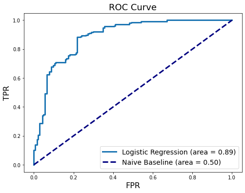

```python
import matplotlib.pyplot as plt
from sklearn.metrics import roc_curve, auc

fpr_1, tpr_1, _ = roc_curve(y_test, y_prob)
roc_auc_1 = auc(fpr_1, tpr_1)

plt.figure(figsize=(8, 6))
plt.title('ROC Curve', fontsize=18)
plt.xlabel('FPR', fontsize=16)
plt.ylabel('TPR', fontsize=16)
plt.plot(fpr_1, tpr_1, lw=3, label='Logistic Regression (area = {:0.2f})'.format(roc_auc_1))
plt.plot([0, 1], [0, 1], color='navy', lw=3, linestyle='--', label='Naive Baseline (area = 0.50)')
plt.legend(loc='lower right', fontsize=14)
plt.show()
```

```python
OSR2_m1= OSR2(logreg, X_test, y_test, y_train)
MSE_m1 = mean_squared_error(y_test, logreg.predict(X_test))
MAE_m1 = mean_absolute_error(y_test, logreg.predict(X_test))
print("OSR2:", OSR2_m1)
print("MSE:", MSE_m1)
print("MAE:", MAE_m1)
```

```
OSR2: 0.48582591587937896
MSE: 0.12855978527033518
MAE: 0.24423602919814855
```

We have performed feature selection by filtering out the variables that have p value greater than 0.05. And the left features are Intercept, pass_rating_diff, TOW,vegas_favorite, and fumbles_lost_diff. The accuracy of the logistic regression model is 0.78 which is reasonably well. Correct positive results occurring among all positive samples available during the test is equal to 0.766 (TPR) and incorrect positive results occur among all negative samples available during the test 0.213 (FPR). This model has OSR2 is equal to 0.486, MSE is equal to 0.129 and MEA is equal to 0.244.

## Model 2: Linear Discriminant Analysis (LDA)

```python
from sklearn.discriminant_analysis import LinearDiscriminantAnalysis
from sklearn.metrics import confusion_matrix
from sklearn.metrics import accuracy_score
from sklearn.metrics import roc_curve
lda = LinearDiscriminantAnalysis()
lda.fit_transform(X_train, y_train)
fitted = lda.fit_transform(X_train, y_train)
y_prob_lda = lda.predict_proba(X_test)
y_pred_lda = pd.Series([1 if x > 1/2 else 0 for x in y_prob_lda[:,1]], index=y_prob.index)
cm_m2 = confusion_matrix(y_test, y_pred_lda)
TPR_m2 = cm_m2.ravel()[3]/(cm_m2.ravel()[3] + cm_m2.ravel()[2])
FPR_m2 = cm_m2.ravel()[1]/(cm_m2.ravel()[1] + cm_m2.ravel()[0])
ACC_m2 = accuracy_score(y_test, y_pred_lda)
print ("Confusion Matrix: \n", cm_m2)
print ("\nAccuracy:", ACC_m2)
print ("\nTPR:",TPR_m2)
print ("\nFPR:",FPR_m2)
```

```
Confusion Matrix:
 [[150  33]
 [ 43 162]]

Accuracy: 0.8041237113402062

TPR: 0.7902439024390244

FPR: 0.18032786885245902
```

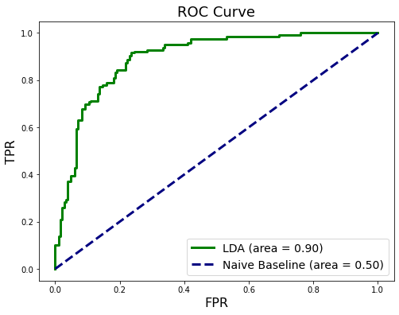

```python
import matplotlib.pyplot as plt
from sklearn.metrics import roc_curve, auc

fpr_2, tpr_2, _ = roc_curve(y_test, y_prob_lda[:,1])
roc_auc_2 = auc(fpr_2, tpr_2)

plt.figure(figsize=(8, 6))
plt.title('ROC Curve', fontsize=18)
plt.xlabel('FPR', fontsize=16)
plt.ylabel('TPR', fontsize=16)
plt.plot(fpr_2, tpr_2, lw=3,color='green', label='LDA (area = {:0.2f})'.format(roc_auc_2))
plt.plot([0, 1], [0, 1], color='navy', lw=3, linestyle='--', label='Naive Baseline (area = 0.50)')
plt.legend(loc='lower right', fontsize=14)
plt.show()
```

```python
OSR2_m2= OSR2(lda, X_test, y_test, y_train)
MSE_m2 = mean_squared_error(y_test, lda.predict(X_test))
MAE_m2 = mean_absolute_error(y_test, lda.predict(X_test))
print("OSR2:", OSR2_m2)
print("MSE:", MSE_m2)
print("MAE:", MAE_m2)
```

```
OSR2: 0.21659396746180248
MSE: 0.1958762886597938
MAE: 0.1958762886597938
```

When we calculate the predicted data by our model we set p value is equal to 0.5 since there is a fifty percent chance that the home team is going to win the match. We get model accuracy is equal to 0.80 and TPR is equal to 0.79 and FPR is equal to 0.18. This model has OSR2 is equal to 0.217, MSE is equal to 0.196 and MEA is equal to 0.196.

## Model 3: Decision Tree Classifier

```python
from sklearn.tree import DecisionTreeClassifier

dtc = DecisionTreeClassifier(min_samples_leaf=5,
                             ccp_alpha=0.001,
                             random_state = 88)

dtc = dtc.fit(X_train, y_train)
```

```
Node count = 89
```

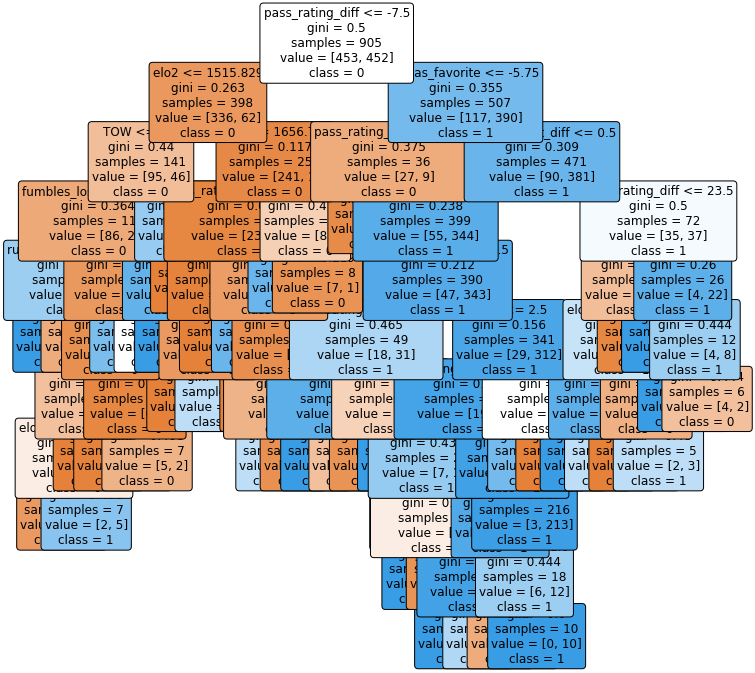

```python
import matplotlib.pyplot as plt
from sklearn.tree import plot_tree

print('Node count =', dtc.tree_.node_count)
plt.figure(figsize=(12,12))
plot_tree(dtc,
          feature_names=X_train.columns,
          class_names=['0','1'],
          filled=True,
          impurity=True,
          rounded=True,
          fontsize=12)
plt.show()
```

```python
# MAKE PREDICTIONS
from sklearn.metrics import confusion_matrix
from sklearn.metrics import precision_score
from sklearn.metrics import recall_score

y_pred = dtc.predict(X_test)
cm_m3 = confusion_matrix(y_test, y_pred)

print ("Confusion Matrix : \n", cm_m3)
# print('Precision:',precision_score(y_test, y_pred))
# print('Recall:',recall_score(y_test, y_pred))

ACC_m3 = (cm_m3.ravel()[0]+cm_m3.ravel()[3])/sum(cm_m3.ravel())
TPR_m3 = cm_m3.ravel()[3]/(cm_m3.ravel()[3]+cm_m3.ravel()[2])
FPR_m3 = cm_m3.ravel()[1]/(cm_m3.ravel()[1]+cm_m3.ravel()[0])
print('Accuracy is: %.4f' %ACC_m3)
print('TPR is: %.4f' % TPR_m3)
print('FPR is: %.4f' % FPR_m3)
```

```
Confusion Matrix :
 [[152  31]
 [ 44 161]]
Accuracy is: 0.8067
TPR is: 0.7854
FPR is: 0.1694
```

Increasing the complexity parameter to prune the tree (the larger ccp_alpha, shallower the tree is).

```
Node count = 37
```

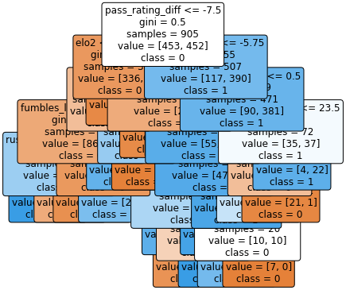

```python
dtc2 = DecisionTreeClassifier(min_samples_leaf=5,
                              ccp_alpha=0.005,
                              random_state = 88)

dtc2 = dtc2.fit(X_train, y_train)

print('Node count =', dtc2.tree_.node_count)
plt.figure(figsize=(6,6))
plot_tree(dtc2,
          feature_names=X_train.columns,
          class_names=['0','1'],
          filled=True,
          impurity=True,
          rounded=True,
          fontsize=12)
plt.show()
```

```python
# MAKE PREDICTIONS
from sklearn.metrics import confusion_matrix
from sklearn.metrics import precision_score
from sklearn.metrics import recall_score

y_pred = dtc2.predict(X_test)
cm = confusion_matrix(y_test, y_pred)

print ("Confusion Matrix : \n", cm)
acc = (cm.ravel()[0]+cm.ravel()[3])/sum(cm.ravel())
TPR = cm.ravel()[3]/(cm.ravel()[3]+cm.ravel()[2])
FPR = cm.ravel()[1]/(cm.ravel()[1]+cm.ravel()[0])
print('Accuracy is: %.4f' %acc)
print('TPR is: %.4f' % TPR)
print('FPR is: %.4f' % FPR)
```

```
Confusion Matrix :
 [[152  31]
 [ 45 160]]
Accuracy is: 0.8041
TPR is: 0.7805
FPR is: 0.1694
```

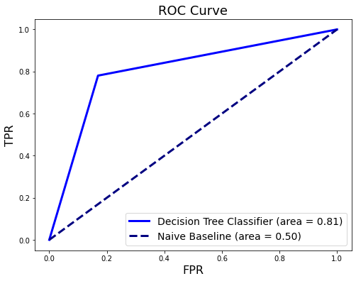

```python
import matplotlib.pyplot as plt
from sklearn.metrics import roc_curve, auc

fpr_3, tpr_3, _ = roc_curve(y_test, y_pred)
roc_auc_3 = auc(fpr_3, tpr_3)

plt.figure(figsize=(8, 6))
plt.title('ROC Curve', fontsize=18)
plt.xlabel('FPR', fontsize=16)
plt.ylabel('TPR', fontsize=16)
plt.plot(fpr_3, tpr_3, lw=3,color='blue', label='Decision Tree Classifier (area = {:0.2f})'.format(roc_auc_3))
plt.plot([0, 1], [0, 1], color='navy', lw=3, linestyle='--', label='Naive Baseline (area = 0.50)')
plt.legend(loc='lower right', fontsize=14)
plt.show()
```

```python
OSR2_m3= OSR2(dtc, X_test, y_test, y_train)
MSE_m3 = mean_squared_error(y_test, dtc.predict(X_test))
MAE_m3 = mean_absolute_error(y_test, dtc.predict(X_test))
print("OSR2:", OSR2_m3)
print("MSE:", MSE_m3)
print("MAE:", MAE_m3)
```

```
OSR2: 0.22690194157414723
MSE: 0.19329896907216496
MAE: 0.19329896907216496
```

We set our complexity parameter (cp) to perform pruning is equal to 0.001 and setting min_samples_leaf=5 which lower the limit of the number of observations in each region. By increasing the complexity parameter ccp_alpha we are pruning the tree and we make the tree shallower. Finally we get accuracy is equal to 0.81, TPR is equal to 0.79 and FPR is equal to 0.17. This model has OSR2 is equal to 0.227, MSE is equal to 0.193 and MEA is equal to 0.193.

## Model 4: Decision Tree Classifier with CV

We are using Decision Tree Classifier with Cross Validation to select best ccp_alpha.

```python
from sklearn.model_selection import GridSearchCV

grid_values = {'ccp_alpha': np.linspace(0, 0.10, 201),
               'min_samples_leaf': [5],
               'min_samples_split': [20],
               'max_depth': [30],
               'class_weight' : [{0: 1, 1: 20}],
               'random_state': [88]}


dtc = DecisionTreeClassifier()
dtc_cv_acc = GridSearchCV(dtc, param_grid = grid_values, scoring = 'accuracy', cv=10, verbose=1)
dtc_cv_acc.fit(X_train, y_train)
```

```
Fitting 10 folds for each of 201 candidates, totalling 2010 fits
```

```
GridSearchCV(cv=10, estimator=DecisionTreeClassifier(),
             param_grid={'ccp_alpha': array([0.    , 0.0005, 0.001 , 0.0015, 0.002 , 0.0025, 0.003 , 0.0035,
       0.004 , 0.0045, 0.005 , 0.0055, 0.006 , 0.0065, 0.007 , 0.0075,
       0.008 , 0.0085, 0.009 , 0.0095, 0.01  , 0.0105, 0.011 , 0.0115,
       0.012 , 0.0125, 0.013 , 0.0135, 0.014 , 0.0145, 0.015 , 0.0155,
       0.016 , 0.0165, 0.017 , 0.0175, 0.018 , 0.0185, 0.019 , 0.0195,
       0.02  , 0.02...
       0.084 , 0.0845, 0.085 , 0.0855, 0.086 , 0.0865, 0.087 , 0.0875,
       0.088 , 0.0885, 0.089 , 0.0895, 0.09  , 0.0905, 0.091 , 0.0915,
       0.092 , 0.0925, 0.093 , 0.0935, 0.094 , 0.0945, 0.095 , 0.0955,
       0.096 , 0.0965, 0.097 , 0.0975, 0.098 , 0.0985, 0.099 , 0.0995,
       0.1   ]),
                         'class_weight': [{0: 1, 1: 20}], 'max_depth': [30],
                         'min_samples_leaf': [5], 'min_samples_split': [20],
                         'random_state': [88]},
             scoring='accuracy', verbose=1)
```

```python
acc = dtc_cv_acc.cv_results_['mean_test_score']
ccp = dtc_cv_acc.cv_results_['param_ccp_alpha'].data
```

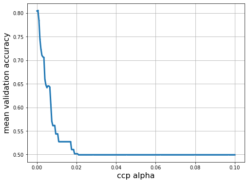

```python
plt.figure(figsize=(8, 6))
plt.xlabel('ccp alpha', fontsize=16)
plt.ylabel('mean validation accuracy', fontsize=16)
plt.scatter(ccp, acc, s=2)
plt.plot(ccp, acc, linewidth=3)
plt.grid(True, which='both')
plt.show()
```

```python
print('Grid best parameter ccp_alpha (max. accuracy): ', dtc_cv_acc.best_params_['ccp_alpha'])
print('Grid best score (accuracy): ', dtc_cv_acc.best_score_)
```

```
Grid best parameter ccp_alpha (max. accuracy):  0.0005
Grid best score (accuracy):  0.8055555555555556
```

```
Node count = 67
```

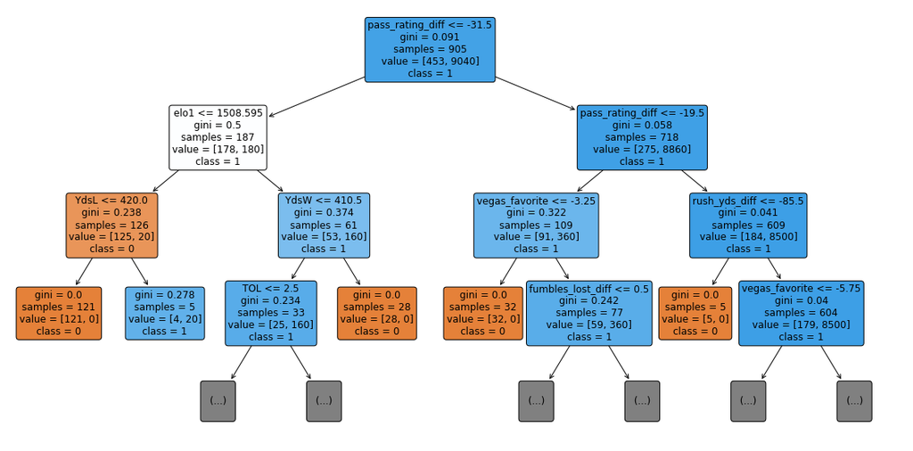

```python
print('Node count =', dtc_cv_acc.best_estimator_.tree_.node_count)

plt.figure(figsize=(20,10))
plot_tree(dtc_cv_acc.best_estimator_,
          feature_names=X_train.columns,
          class_names=['0','1'],
          filled=True,
          impurity=True,
          rounded=True,
          fontsize=12,
          max_depth=3)
plt.show()
```

```python
y_pred = dtc_cv_acc.best_estimator_.predict(X_test)
cm_m4 = confusion_matrix(y_test, y_pred)

print ("Confusion Matrix : \n", cm_m4)

ACC_m4 = (cm_m4.ravel()[0]+cm_m4.ravel()[3])/sum(cm_m4.ravel())
TPR_m4 = cm_m4.ravel()[3]/(cm_m4.ravel()[3]+cm_m4.ravel()[2])
FPR_m4 = cm_m4.ravel()[1]/(cm_m4.ravel()[1]+cm_m4.ravel()[0])
print('Accuracy is: %.4f' %ACC_m4)
print('TPR is: %.4f' % TPR_m4)
print('FPR is: %.4f' % FPR_m4)
```

```
Confusion Matrix :
 [[123  60]
 [ 10 195]]
Accuracy is: 0.8196
TPR is: 0.9512
FPR is: 0.3279
```

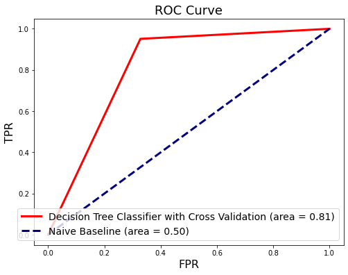

```python
import matplotlib.pyplot as plt
from sklearn.metrics import roc_curve, auc

fpr_4, tpr_4, _ = roc_curve(y_test, y_pred)
roc_auc_4 = auc(fpr_4, tpr_4)

plt.figure(figsize=(8, 6))
plt.title('ROC Curve', fontsize=18)
plt.xlabel('FPR', fontsize=16)
plt.ylabel('TPR', fontsize=16)
plt.plot(fpr_4, tpr_4, lw=3,color='red', label='Decision Tree Classifier with Cross Validation (area = {:0.2f})'.format(roc_auc_4))
plt.plot([0, 1], [0, 1], color='navy', lw=3, linestyle='--', label='Naive Baseline (area = 0.50)')
plt.legend(loc='lower right', fontsize=14)
plt.show()
```

```python
OSR2_m4= OSR2(dtc_cv_acc, X_test, y_test, y_train)
MSE_m4 = mean_squared_error(y_test, dtc_cv_acc.predict(X_test))
MAE_m4 = mean_absolute_error(y_test, dtc_cv_acc.predict(X_test))
print("OSR2:", OSR2_m4)
print("MSE:", MSE_m4)
print("MAE:", MAE_m4)
```

```
OSR2: 0.2784418121358707
MSE: 0.18041237113402062
MAE: 0.18041237113402062
```

## Model 5: Random Forest Classifier

```python
from sklearn.ensemble import RandomForestClassifier

rf = RandomForestClassifier(max_features=5, min_samples_leaf=5, n_estimators=500, random_state=88)
rf.fit(X_train, y_train)
```

```
RandomForestClassifier(max_features=5, min_samples_leaf=5, n_estimators=500,
                       random_state=88)
```

```python
y_pred = rf.predict(X_test)
cm_m5 = confusion_matrix(y_test, y_pred)
TPR_m5 = cm_m5.ravel()[3]/(cm_m5.ravel()[3]+cm_m5.ravel()[2])
FPR_m5 = cm_m5.ravel()[1]/(cm_m5.ravel()[1]+cm_m5.ravel()[0])
ACC_m5 = accuracy_score(y_test, y_pred)
print ("Confusion Matrix: \n", cm_m5)
print ("\nAccuracy:", ACC_m5)
print('TPR is: %.4f' % TPR_m5)
print('FPR is: %.4f' % FPR_m5)
```

```
Confusion Matrix:
 [[160  23]
 [ 26 179]]

Accuracy: 0.8737113402061856
TPR is: 0.8732
FPR is: 0.1257
```

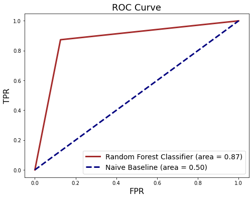

```python
import matplotlib.pyplot as plt
from sklearn.metrics import roc_curve, auc

fpr_5, tpr_5, _ = roc_curve(y_test, y_pred)
roc_auc_5 = auc(fpr_5, tpr_5)

plt.figure(figsize=(8, 6))
plt.title('ROC Curve', fontsize=18)
plt.xlabel('FPR', fontsize=16)
plt.ylabel('TPR', fontsize=16)
plt.plot(fpr_5, tpr_5, lw=3,color='brown', label='Random Forest Classifier (area = {:0.2f})'.format(roc_auc_5))
plt.plot([0, 1], [0, 1], color='navy', lw=3, linestyle='--', label='Naive Baseline (area = 0.50)')
plt.legend(loc='lower right', fontsize=14)
plt.show()
```

```python
OSR2_m5= OSR2(rf, X_test, y_test, y_train)
MSE_m5 = mean_squared_error(y_test, rf.predict(X_test))
MAE_m5 = mean_absolute_error(y_test, rf.predict(X_test))
print("OSR2:", OSR2_m5)
print("MSE:", MSE_m5)
print("MAE:", MAE_m5)
```

```
OSR2: 0.4949092684951095
MSE: 0.12628865979381443
MAE: 0.12628865979381443
```

The minimum number of samples required to be at a leaf node is set to 5. We get model accuracy equal to 0.874 and TPR is equal to 0.873 and FPR is equal to 0.126. This model has OSR2 is equal to 0.495, MSE is equal to 0.126 and MEA is equal to 0.126.

## Gradient Boosting with CV Model6

```python
from sklearn.ensemble import GradientBoostingClassifier
grid_values  =  {'n_estimators':  np.linspace(100,  700,  7,  dtype='int32'), 'learning_rate': [0.01,0.1],
'max_features': ["sqrt", "log2"], 'min_samples_split':  [50,200,500,1000,2000],
'random_state':  [88]}
gbc = GradientBoostingClassifier()
gbc_cv  =  GridSearchCV(gbc,  param_grid=grid_values,  cv=5,  n_jobs=-1)
gbc_cv.fit(X_train, y_train)
```

```
GridSearchCV(cv=5, estimator=GradientBoostingClassifier(), n_jobs=-1,
             param_grid={'learning_rate': [0.01, 0.1],
                         'max_features': ['sqrt', 'log2'],
                         'min_samples_split': [50, 200, 500, 1000, 2000],
                         'n_estimators': array([100, 200, 300, 400, 500, 600, 700], dtype=int32),
                         'random_state': [88]})
```

```python
print('OSR2:', round(OSR2(gbc_cv, X_test, y_test, y_train), 5))
```

```
OSR2: 0.7423
```

```python
y_pred = gbc_cv.predict(X_test)
cm_m6 = confusion_matrix(y_test, y_pred)
TPR_m6 = cm_m6.ravel()[3]/(cm_m6.ravel()[3]+cm_m6.ravel()[2])
FPR_m6 = cm_m6.ravel()[1]/(cm_m6.ravel()[1]+cm_m6.ravel()[0])
ACC_m6 = accuracy_score(y_test, y_pred)
print ("Confusion Matrix: \n", cm_m6)
print ("\nAccuracy:", ACC_m6)
print('TPR is: %.4f' % TPR_m6)
print('FPR is: %.4f' % FPR_m6)
```

```
Confusion Matrix:
 [[175   8]
 [ 17 188]]

Accuracy: 0.9355670103092784
TPR is: 0.9171
FPR is: 0.0437
```

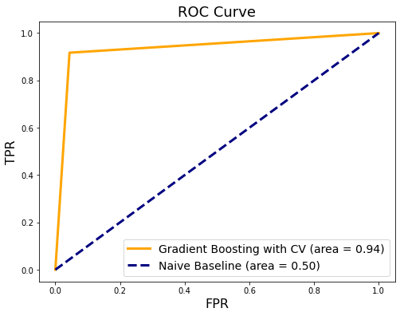

```python
import matplotlib.pyplot as plt
from sklearn.metrics import roc_curve, auc

fpr_6, tpr_6, _ = roc_curve(y_test, y_pred)
roc_auc_6 = auc(fpr_6, tpr_6)

plt.figure(figsize=(8, 6))
plt.title('ROC Curve', fontsize=18)
plt.xlabel('FPR', fontsize=16)
plt.ylabel('TPR', fontsize=16)
plt.plot(fpr_6, tpr_6, lw=3,color='orange', label='Gradient Boosting with CV (area = {:0.2f})'.format(roc_auc_6))
plt.plot([0, 1], [0, 1], color='navy', lw=3, linestyle='--', label='Naive Baseline (area = 0.50)')
plt.legend(loc='lower right', fontsize=14)
plt.show()
```

```python
OSR2_m6= OSR2(gbc_cv, X_test, y_test, y_train)
MSE_m6 = mean_squared_error(y_test, gbc_cv.predict(X_test))
MAE_m6 = mean_absolute_error(y_test, gbc_cv.predict(X_test))
print("OSR2:", OSR2_m6)
print("MSE:", MSE_m6)
print("MAE:", MAE_m6)
```

```
OSR2: 0.7423006471913824
MSE: 0.06443298969072164
MAE: 0.06443298969072164
```

We set cv=5 inside GridSearchCV. We get model accuracy equal to 0.936 and TPR is equal to 0.917 and FPR is equal to 0.044. This model has OSR2 is equal to 0.742, MSE is equal to 0.064 and MEA is equal to 0.064.

# Choosing the Best Model

```python
data_fin = [ (acc_baseline, 0 , 0, 0, 0, 0) ,
            (ACC_m1, TPR_m1, FPR_m1, OSR2_m1, MSE_m1, MAE_m1) ,
             (ACC_m2, TPR_m2, FPR_m2, OSR2_m2, MSE_m2, MAE_m2) ,
            (ACC_m3, TPR_m3, FPR_m3, OSR2_m3, MSE_m3, MAE_m3) ,
             ( ACC_m4, TPR_m4, FPR_m4, OSR2_m4, MSE_m4, MAE_m4),
               ( ACC_m5, TPR_m5, FPR_m5, OSR2_m5, MSE_m5, MAE_m5),
               ( ACC_m6, TPR_m6, FPR_m6, OSR2_m6, MSE_m6, MAE_m6)
               ]

final_data_frame = pd.DataFrame(data_fin, columns = ['ACC', 'TPR','FPR', "OSR2", "MSE", "MAE" ],
                     index=['BaseLine Model', 'Logistic Regression Model1',
                            'LDA Model2' ,'Decision Tree Classifier Model3',
                            'Decision Tree Classifier with CV Model4',
                           'Random Forest Classifier Model5',
                           'Gradient Boosting with CV Model6',])
```

```python
final_data_frame.round(3)
```

|  | ACC | TPR | FPR | OSR2 | MSE | MAE |
| --- | --- | --- | --- | --- | --- | --- |
| BaseLine Model | 0.528 | 0.000 | 0.000 | 0.000 | 0.000 | 0.000 |
| Logistic Regression Model1 | 0.776 | 0.766 | 0.213 | 0.486 | 0.129 | 0.244 |
| LDA Model2 | 0.804 | 0.790 | 0.180 | 0.217 | 0.196 | 0.196 |
| Decision Tree Classifier Model3 | 0.807 | 0.785 | 0.169 | 0.227 | 0.193 | 0.193 |
| Decision Tree Classifier with CV Model4 | 0.820 | 0.951 | 0.328 | 0.278 | 0.180 | 0.180 |
| Random Forest Classifier Model5 | 0.874 | 0.873 | 0.126 | 0.495 | 0.126 | 0.126 |
| Gradient Boosting with CV Model6 | 0.936 | 0.917 | 0.044 | 0.742 | 0.064 | 0.064 |

[figure not shown]

```python
import matplotlib.pyplot as plt
from sklearn.metrics import roc_curve, auc

fpr, tpr, _ = roc_curve(y_test, y_pred)
roc_auc = auc(fpr, tpr)

plt.figure(figsize=(8, 6))
plt.title('ROC Curve', fontsize=30)
plt.xlabel('FPR', fontsize=16)
plt.ylabel('TPR', fontsize=16)
plt.plot(fpr_1, tpr_1, lw=3, label='Logistic Regression (area = {:0.2f})'.format(roc_auc_1))
plt.plot(fpr_2, tpr_2, lw=3,color='green', label='LDA (area = {:0.2f})'.format(roc_auc_2))
plt.plot(fpr_3, tpr_3, lw=3,color='blue', label='Decision Tree Classifier (area = {:0.2f})'.format(roc_auc))
plt.plot(fpr_4, tpr_4, lw=3,color='red', label='Decision Tree Classifier with Cross Validation (area = {:0.2f})'.format(roc_auc_4))
plt.plot(fpr_5, tpr_5, lw=3,color='brown', label='Random Forest Classifier (area = {:0.2f})'.format(roc_auc_5))
plt.plot(fpr_6, tpr_6, lw=3,color='orange', label='Gradient Boosting with CV (area = {:0.2f})'.format(roc_auc_6))
plt.plot([0, 1], [0, 1], color='navy', lw=3, linestyle='--', label='Naive Baseline (area = 0.50)')
plt.legend(loc='lower right', fontsize=10)
plt.show()
```

# Feature Analysis

Correlation analysis of each individual feature with target variable(Is_HomeTeam_Win).

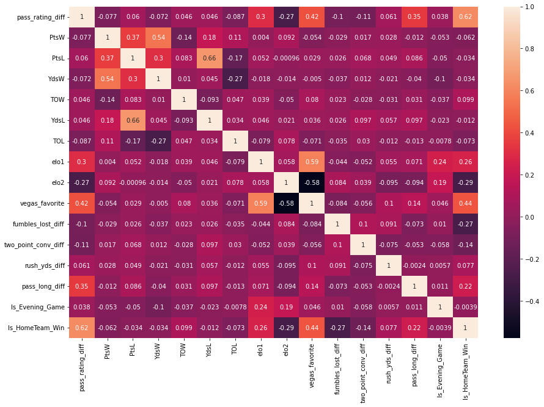

```python
import matplotlib.pyplot as plt
import seaborn as sns

plt.figure(figsize=(15, 10))
sns.heatmap(dataLast.corr(), annot=True)
```

```python
corr = dataLast.corr()
newdata_st = corr.style.background_gradient(cmap='coolwarm').data
newdata_st["Is_HomeTeam_Win"].sort_values(ascending=False).head(5)
```

```
Is_HomeTeam_Win     1.000000
pass_rating_diff    0.619360
vegas_favorite      0.435342
elo1                0.259412
pass_long_diff      0.223269
Name: Is_HomeTeam_Win, dtype: float64
```

Correlation analysis of each individual feature with target variable(Is_HomeTeam_Win). The last row on the plot is our target variable and the most important features for the team in order to win the game are pass_rating_diff = 0.62, vegas_favorite = 0.44, elo1 = 0.26 and pass_long_diff = 0.22 because they have high correlation.